# 클린업 1주차 패키지

2017314423 위재성

## Chapter 1 전처리

#### 문제0. (기본 세팅) 0번 txt파일을 실행하세요.

(패키지 불러오기, 디렉토리 설정 및 데이터 불러오기)

```r
## 디렉토리 설정
setwd("C:/Users/위재성/Desktop/Psat/2학기/Package/클린업 1주차 패키지")  ## 본인의 디렉토리로 변경하세요.

# 패키지 불러오기 -- 아래의 패키지 이외에는 부르지 말아주세요!
library(tidyverse)
library(magrittr)
library(data.table)
library(ggpubr)
library(corrplot)
library(caret)
library(Metrics)

# 데이터 불러오기
cus_info <- fread("cus_info.csv",
                  header=TRUE,
                  data.table = FALSE,
                  stringsAsFactors = FALSE,
                  na.strings = c("_", "-"))

act_info <- fread("act_info.csv",
                  header=TRUE,
                  data.table = FALSE,
                  stringsAsFactors = FALSE)
```

#### 문제1. 데이터의 기본 구조를 파악하고 데이터 개수, 변수 개수, 데이터 형식을 확인해보세요.

(head, tail, str, glimpse, summary 등 다양하게 사용해보세요)

```r
#act_info
act_info %>% head(3)
```

```
##                                                             act_id
## 1 8e1a987ebef2a3374ba558aeda4c7821de7808a11cfea1e149438ae91f1d4c79
## 2 eb161b66263589c3f38efd2277cec2a9a81e1ffa0a5255931265d35f4b064b67
## 3 01866857515304e9e1315e54863cc1108e1d46fff0d467fe1d405b96a06ece0c
##                                                             cus_id act_opn_ym
## 1 892f41b5002a79c9c93992acf60682f5698372aea023bda68d942687109ae8ab     197912
## 2 006ad32069efb2a8ce1a99542dfe41cb14e8e75685278a3ce127ab83d04fbafa     198702
## 3 1925ed2d8ed2cad53997f5b24722482137c4d1da4b555e9217722a3b3397f9ab     199109
```

```r
act_info %>% tail(3)
```

```
##                                                                 act_id
## 23957 4bf846f46e7c0b8547a2e04caf6573976eb621156f3032473b89f049bdc40e4c
## 23958 bdb499007eb246137859668816eebddde9bfeb3efaec8e89a34b4d49dae717a0
## 23959 3e5168a7d5ec0efd23f240bd5d9530e4285ff9e661e81c839d222de23a58a18a
##                                                                 cus_id
## 23957 0931f895fe62bcdf3918b0ad6271c76d4f1934ff0e36ebc0433c904a358eaee1
## 23958 24653394d720670b49b1146b2793481bdca7aa7a84d11c1eb5ce825954a251c5
## 23959 de85269c18672536604fd60cb06a616ab9dab4dafb804c698dce4f835f662855
##       act_opn_ym
## 23957     201201
## 23958     199712
## 23959     200203
```

```r
act_info %>% summary()
```

```
##     act_id             cus_id            act_opn_ym
##  Length:23959       Length:23959       Min.   :     0
##  Class :character   Class :character   1st Qu.:200509
##  Mode  :character   Mode  :character   Median :201507
##                                        Mean   :201137
##                                        3rd Qu.:201907
##                                        Max.   :202010
```

```r
act_info %>% glimpse()
```

```
## Rows: 23,959
## Columns: 3
## $ act_id     <chr> "8e1a987ebef2a3374ba558aeda4c7821de7808a11cfea1e149438ae91f~
## $ cus_id     <chr> "892f41b5002a79c9c93992acf60682f5698372aea023bda68d94268710~
## $ act_opn_ym <int> 197912, 198702, 199109, 199401, 199404, 199412, 199507, 199~
```

```r
act_info %>% str()
```

```
## 'data.frame':    23959 obs. of  3 variables:
##  $ act_id    : chr  "8e1a987ebef2a3374ba558aeda4c7821de7808a11cfea1e149438ae91f1d4c79" "eb161b66263589c3f38efd2277cec2a9a81e1ffa0a5255931265d35f4b064b67" "01866857515304e9e1315e54863cc1108e1d46fff0d467fe1d405b96a06ece0c" "63a58b0fee2fa4dc467c043fde465846b65705659497c5e627b43247b221a143" ...
##  $ cus_id    : chr  "892f41b5002a79c9c93992acf60682f5698372aea023bda68d942687109ae8ab" "006ad32069efb2a8ce1a99542dfe41cb14e8e75685278a3ce127ab83d04fbafa" "1925ed2d8ed2cad53997f5b24722482137c4d1da4b555e9217722a3b3397f9ab" "7829365dc463ed8275c8b92518d58b3c8d983f00f7bf87ba7e567981e13a1f3a" ...
##  $ act_opn_ym: int  197912 198702 199109 199401 199404 199412 199507 199508 199508 199601 ...
```

```r
#cus_info
cus_info %>% head(3)
```

```
##                                                             cus_id sex_dit_cd
## 1 1eec7e43dd6ea34d6be7a9484459e4db1a2da44c5bf311aed5389a2c6ce92b60          2
## 2 7e50c268acce884b1a5b78c9b5645b517c4639413c6dc4d7de50799cedab4480          2
## 3 36d3cd293c4b02a00103fa1ba33ffbee176173a55df75b1e7ee7d7d24ee55523          1
##   cus_age zip_ctp_cd tco_cus_grd_cd ivs_icn_cd
## 1      20         29              4         NA
## 2       0         41              9         NA
## 3      70         27              3         NA
```

```r
cus_info %>% tail(3)
```

```
##                                                                 cus_id
## 9998  347190a59df83bbf2d87888915b95cd5b5c52fb781a45ec29fdf17b46816588b
## 9999  3ae218361d32511eec17e92b139f048ec2613ff6d56ac9aa208673761a1ac632
## 10000 7bdea48b84cc322b3ef7d0b934d505afd467e11879571f501c0c8ca738eeec70
##       sex_dit_cd cus_age zip_ctp_cd tco_cus_grd_cd ivs_icn_cd
## 9998           2      35         11              9         NA
## 9999           1      35         31              5         NA
## 10000          1      35         48              9         NA
```

```r
cus_info %>% summary()
```

```
##     cus_id            sex_dit_cd       cus_age        zip_ctp_cd
##  Length:10000       Min.   :1.000   Min.   : 0.00   Min.   :11.00
##  Class :character   1st Qu.:1.000   1st Qu.:35.00   1st Qu.:26.00
##  Mode  :character   Median :1.000   Median :45.00   Median :41.00
##                     Mean   :1.381   Mean   :42.17   Mean   :32.01
##                     3rd Qu.:2.000   3rd Qu.:50.00   3rd Qu.:42.00
##                     Max.   :2.000   Max.   :70.00   Max.   :50.00
##                                                     NA's   :40
##  tco_cus_grd_cd    ivs_icn_cd
##  Min.   :1.000   Min.   :0.000
##  1st Qu.:4.000   1st Qu.:3.000
##  Median :5.000   Median :3.000
##  Mean   :5.476   Mean   :3.316
##  3rd Qu.:9.000   3rd Qu.:4.000
##  Max.   :9.000   Max.   :9.000
##  NA's   :638     NA's   :4308
```

```r
cus_info %>% glimpse()
```

```
## Rows: 10,000
## Columns: 6
## $ cus_id         <chr> "1eec7e43dd6ea34d6be7a9484459e4db1a2da44c5bf311aed5389a~
## $ sex_dit_cd     <int> 2, 2, 1, 1, 1, 1, 1, 1, 1, 1, 1, 1, 1, 2, 2, 2, 2, 1, 1~
## $ cus_age        <int> 20, 0, 70, 70, 70, 70, 70, 70, 70, 70, 70, 70, 70, 70, ~
## $ zip_ctp_cd     <int> 29, 41, 27, 41, 11, 28, 11, 11, 26, 43, 44, 26, 41, 11,~
## $ tco_cus_grd_cd <int> 4, 9, 3, 9, 5, 4, 1, 2, 2, 4, 4, 3, 3, 1, 1, NA, 3, 5, ~
## $ ivs_icn_cd     <int> NA, NA, NA, NA, NA, NA, 4, 4, NA, 4, 3, NA, 3, 4, 4, 2,~
```

```r
cus_info %>% str()
```

```
## 'data.frame':    10000 obs. of  6 variables:
##  $ cus_id        : chr  "1eec7e43dd6ea34d6be7a9484459e4db1a2da44c5bf311aed5389a2c6ce92b60" "7e50c268acce884b1a5b78c9b5645b517c4639413c6dc4d7de50799cedab4480" "36d3cd293c4b02a00103fa1ba33ffbee176173a55df75b1e7ee7d7d24ee55523" "96b6dea03dc71d9ddb1462e06fdba23def1ddc838debf7cba4484f9f7d9b6631" ...
##  $ sex_dit_cd    : int  2 2 1 1 1 1 1 1 1 1 ...
##  $ cus_age       : int  20 0 70 70 70 70 70 70 70 70 ...
##  $ zip_ctp_cd    : int  29 41 27 41 11 28 11 11 26 43 ...
##  $ tco_cus_grd_cd: int  4 9 3 9 5 4 1 2 2 4 ...
##  $ ivs_icn_cd    : int  NA NA NA NA NA NA 4 4 NA 4 ...
```

#### 문제2. 각 열별로 결측치(NA)의 개수를 확인한 후 결측치가 40% 이상인 열을 삭제하세요.

(colSums 사용 시 편리)

```r
act_info %>% is.na %>% colSums
```

```
##     act_id     cus_id act_opn_ym
##          0          0          0
```

```r
cus_info %>% is.na %>% colSums
```

```
##         cus_id     sex_dit_cd        cus_age     zip_ctp_cd tco_cus_grd_cd
##              0              0              0             40            638
##     ivs_icn_cd
##           4308
```

```r
nrow(cus_info) * 0.4
```

```
## [1] 4000
```

ivs_icn_cd열의 결측치가 4000개 넘으므로 삭제

```r
cus_info %<>% select(-ivs_icn_cd)
```

#### 문제3. 각 열마다 unique한 값의 개수를 확인하세요.

(apply, n_distinct 사용 시 편리)

```r
act_info %>% apply(2, n_distinct)
```

```
##     act_id     cus_id act_opn_ym
##      23959      10000        418
```

```r
cus_info %>% apply(2, n_distinct)
```

```
##         cus_id     sex_dit_cd        cus_age     zip_ctp_cd tco_cus_grd_cd
##          10000              2             12             18              7
```

#### 문제4. act_info에서 계좌개설일(act_opn_ym)의 unique 값을 확인 후 이상치값을 갖는 행 을 삭제하세요.

```r
act_info[,'act_opn_ym'] %>% unique()
```

```
##   [1] 197912 198702 199109 199401 199404 199412 199507 199508 199601 199603
##  [11] 199706 199111 199112 199210 199311 199911 200003 200502 199904 199907
##  [21] 199909 200001 200002 200004 200005 200104 200105 200108 199605 199303
##  [31] 200305 200307 200403 200407 200409 199703 200504 199211 199407 199501
##  [41] 199408 199711 200408 200511 200512 200602 200702 200703 200704 200706
##  [51] 200707 200708 200710 200711 200801 200807 200809 199405 199410 201310
##  [61] 201211 201507 200303 200501 201712 200505 201503 200808 201603 200912
##  [71] 202008 201311 201610 201606 201410 201705 201708 201706 201810 201906
##  [81] 200101 200211 200611 200604 200612 200509 198812 198903 198908 198910
##  [91] 199007 199105 199512 200006 198911 199101 199102 199110 199208 199704
## [101] 199812 199306 199310 200012 200111 200112 199610 200312 199509 199905
## [111] 199403 199607 199802 199712 200404 200210 200308 199803 199809 200507
## [121] 200603 200705 199411 199006 199510 199709 199805 199906 199801 199912
## [131] 200301 200401 200607 199304 200802 200608 199203 198707 200610 200605
## [141] 198810 199406 199504 199903 199910 200007 200106 200402 200803 200811
```

[output cut: 27 more lines]

```r
# 이상치인 0값 제거 후 분포 재확인
act_info %<>% filter(act_opn_ym != 0)
act_info[, 'act_opn_ym'] %>% summary()
```

```
##    Min. 1st Qu.  Median    Mean 3rd Qu.    Max.
##  197603  200509  201507  201154  201907  202010
```

#### 문제5. act_info에서 계좌개설일(act_opn_ym) 변수를 각각 년(act_opn_yy) 변수와 월(act_opn_mm) 변수로 나눈 뒤 수치형 변수로 변환 하세요.

(separate 사용 시 편리)

```r
act_info %<>% separate(act_opn_ym, into = c('act_opn_yy','act_opn_mm'), sep=4)
act_info[, c('act_opn_yy')] %<>% as.numeric()
act_info[, c('act_opn_mm')] %<>% as.numeric()

act_info %>% head(3) # 년, 월 변수 잘 나뉘어진 것 확인
```

```
##                                                             act_id
## 1 8e1a987ebef2a3374ba558aeda4c7821de7808a11cfea1e149438ae91f1d4c79
## 2 eb161b66263589c3f38efd2277cec2a9a81e1ffa0a5255931265d35f4b064b67
## 3 01866857515304e9e1315e54863cc1108e1d46fff0d467fe1d405b96a06ece0c
##                                                             cus_id act_opn_yy
## 1 892f41b5002a79c9c93992acf60682f5698372aea023bda68d942687109ae8ab       1979
## 2 006ad32069efb2a8ce1a99542dfe41cb14e8e75685278a3ce127ab83d04fbafa       1987
## 3 1925ed2d8ed2cad53997f5b24722482137c4d1da4b555e9217722a3b3397f9ab       1991
##   act_opn_mm
## 1         12
## 2          2
## 3          9
```

```r
act_info %>% str() # 수치형 변수로 변환 확인
```

```
## 'data.frame':    23957 obs. of  4 variables:
##  $ act_id    : chr  "8e1a987ebef2a3374ba558aeda4c7821de7808a11cfea1e149438ae91f1d4c79" "eb161b66263589c3f38efd2277cec2a9a81e1ffa0a5255931265d35f4b064b67" "01866857515304e9e1315e54863cc1108e1d46fff0d467fe1d405b96a06ece0c" "63a58b0fee2fa4dc467c043fde465846b65705659497c5e627b43247b221a143" ...
##  $ cus_id    : chr  "892f41b5002a79c9c93992acf60682f5698372aea023bda68d942687109ae8ab" "006ad32069efb2a8ce1a99542dfe41cb14e8e75685278a3ce127ab83d04fbafa" "1925ed2d8ed2cad53997f5b24722482137c4d1da4b555e9217722a3b3397f9ab" "7829365dc463ed8275c8b92518d58b3c8d983f00f7bf87ba7e567981e13a1f3a" ...
##  $ act_opn_yy: num  1979 1987 1991 1994 1994 ...
##  $ act_opn_mm: num  12 2 9 1 4 12 7 8 8 1 ...
```

#### 문제6. cus_info에서 범주형 변수인데 수치형으로 읽힌 경우 mutate_if를 통해 범주형 변수로 변경 하세요.

```r
cus_info %>% str()
```

```
## 'data.frame':    10000 obs. of  5 variables:
##  $ cus_id        : chr  "1eec7e43dd6ea34d6be7a9484459e4db1a2da44c5bf311aed5389a2c6ce92b60" "7e50c268acce884b1a5b78c9b5645b517c4639413c6dc4d7de50799cedab4480" "36d3cd293c4b02a00103fa1ba33ffbee176173a55df75b1e7ee7d7d24ee55523" "96b6dea03dc71d9ddb1462e06fdba23def1ddc838debf7cba4484f9f7d9b6631" ...
##  $ sex_dit_cd    : int  2 2 1 1 1 1 1 1 1 1 ...
##  $ cus_age       : int  20 0 70 70 70 70 70 70 70 70 ...
##  $ zip_ctp_cd    : int  29 41 27 41 11 28 11 11 26 43 ...
##  $ tco_cus_grd_cd: int  4 9 3 9 5 4 1 2 2 4 ...
```

```r
# 나이 제외 모두 범주형 변수이므로 변경
cus_info[,-3] %<>% mutate_if(is.integer, as.factor)
cus_info %>% str() # 범주형으로 변경 확인
```

```
## 'data.frame':    10000 obs. of  5 variables:
##  $ cus_id        : chr  "1eec7e43dd6ea34d6be7a9484459e4db1a2da44c5bf311aed5389a2c6ce92b60" "7e50c268acce884b1a5b78c9b5645b517c4639413c6dc4d7de50799cedab4480" "36d3cd293c4b02a00103fa1ba33ffbee176173a55df75b1e7ee7d7d24ee55523" "96b6dea03dc71d9ddb1462e06fdba23def1ddc838debf7cba4484f9f7d9b6631" ...
##  $ sex_dit_cd    : Factor w/ 2 levels "1","2": 2 2 1 1 1 1 1 1 1 1 ...
##  $ cus_age       : int  20 0 70 70 70 70 70 70 70 70 ...
##  $ zip_ctp_cd    : Factor w/ 17 levels "11","26","27",..: 5 9 3 9 1 4 1 1 2 11 ...
##  $ tco_cus_grd_cd: Factor w/ 6 levels "1","2","3","4",..: 4 6 3 6 5 4 1 2 2 4 ...
```

#### 문제7. cus_info에서 연령대(cus_age) 변수를 10세 기준으로 재범주화 하세요.

(데이터 명세 참고)

```r
cus_info[,'cus_age'] %>% summary
```

```
##    Min. 1st Qu.  Median    Mean 3rd Qu.    Max.
##    0.00   35.00   45.00   42.17   50.00   70.00
```

```r
#0-70까지 분포
cus_info[,"cus_age"] %<>% cut(breaks= c(10*(0:8)),
                              labels = c('10s','10s','20s','30s','40s','50s','60s','70s'),
                              right = FALSE) #  (0,10] -> [0,10)
cus_info[,'cus_age'] %>% summary #재범주화 확인
```

```
##  10s  20s  30s  40s  50s  60s  70s
##  212 1254 2164 2798 2259  959  354
```

#### 문제8. 데이터 레이블 변경하기

```r
# 성별 레이블 변경
cus_info[, 'sex_dit_cd'] = ifelse(cus_info[, "sex_dit_cd"] == 1, 'M', 'F')
# 지역 레이블 변경
cus_info %<>%
  mutate(zip_ctp_cd = case_when(zip_ctp_cd == 41 ~ '경기',
                               zip_ctp_cd == 11 ~ '서울',
                               zip_ctp_cd == 48 ~ '경남',
                               zip_ctp_cd == 26 ~ '부산',
                               zip_ctp_cd == 27 ~ '대구',
                               zip_ctp_cd == 47 ~ '경북',
                               zip_ctp_cd == 28 ~ '인천',
                               zip_ctp_cd == 44 ~ '충남',
                               zip_ctp_cd == 46 ~ '전남',
                               zip_ctp_cd == 30 ~ '대전',
                               zip_ctp_cd == 29 ~ '광주',
                               zip_ctp_cd == 43 ~ '충북',
                               zip_ctp_cd == 45 ~ '전북',
                               zip_ctp_cd == 42 ~ '강원',
                               zip_ctp_cd == 31 ~ '울산',
                               zip_ctp_cd == 50 ~ '제주',
                               zip_ctp_cd == 36 ~ '세종'
                               ))
cus_info[,'zip_ctp_cd'] %>% unique() # NA 제외 총 17개 지역 잘 나옴.
```

```
##  [1] "광주" "경기" "대구" "서울" "인천" "부산" "충북" "충남" "울산" "전남"
## [11] "경북" "제주" "강원" "경남" "전북" "대전" NA     "세종"
```

#### 문제9. cus_id를 제외한 모든 변수들을 factor 형태로 변경 한 후 자료형태를 다시 확인해보세요.

```r
cus_info[,-1] %<>% mutate_if(is.character, as.factor) # 레이블 변경으로 인한 문자형 변수 변환
cus_info %>% str()
```

```
## 'data.frame':    10000 obs. of  5 variables:
##  $ cus_id        : chr  "1eec7e43dd6ea34d6be7a9484459e4db1a2da44c5bf311aed5389a2c6ce92b60" "7e50c268acce884b1a5b78c9b5645b517c4639413c6dc4d7de50799cedab4480" "36d3cd293c4b02a00103fa1ba33ffbee176173a55df75b1e7ee7d7d24ee55523" "96b6dea03dc71d9ddb1462e06fdba23def1ddc838debf7cba4484f9f7d9b6631" ...
##  $ sex_dit_cd    : Factor w/ 2 levels "F","M": 1 1 2 2 2 2 2 2 2 2 ...
##  $ cus_age       : Factor w/ 7 levels "10s","20s","30s",..: 2 1 7 7 7 7 7 7 7 7 ...
##  $ zip_ctp_cd    : Factor w/ 17 levels "강원","경기",..: 5 2 6 2 9 12 9 9 8 17 ...
##  $ tco_cus_grd_cd: Factor w/ 6 levels "1","2","3","4",..: 4 6 3 6 5 4 1 2 2 4 ...
```

#### 문제10. 문제 4번의 결과를 바탕으로 두 데이터셋을 병합한 뒤 data로 저장하고 이전 데이터셋은 삭제하세요.

```r
data = merge(cus_info,act_info,by='cus_id') # 고객 번호 기준으로 병합
rm(list = c('act_info','cus_info'))
```

#### 문제11. 연령대별(cus_age)로 그룹화하여 고객 수(cus_cnt), 계좌 수(act_cnt), 그리고 1인당 평균 계좌 개수(mean_act_cnt) 파생변수를 만드세요. 이후의 시각화에 사용하기 위해 account__cnt로 저장하세요.

```r
account__cnt = data %>%
  group_by(cus_age) %>% # 연령대별 그룹화
  summarise(cus_cnt = length(unique(cus_id)), # 고객 번호 개수
            act_cnt = length(unique(act_id)), # 계좌 번호 개수
            mean_act_cnt = act_cnt / cus_cnt)
```

## Chapter 2 시각화

### 문제1. Bar Graph

#### 1-1. data의 각 변수별 결측치 개수와 비율을 다음과 같이 시각화해서 보여주세요.

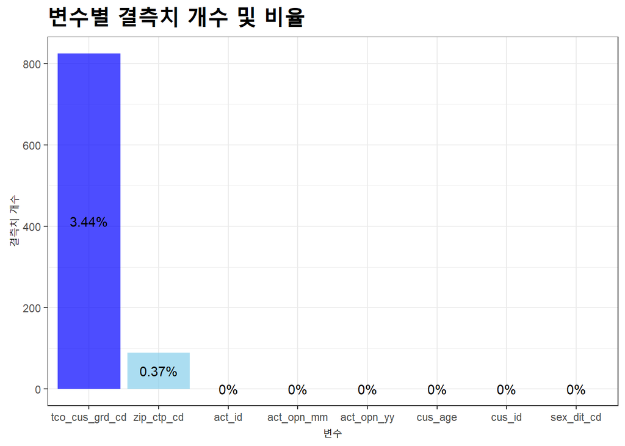

```r
# 변수별 결측치 개수와 비율 데이터프레임
na_data = data.frame(var = data %>% colnames(),
                     na = data %>% is.na %>% colSums,
                     prop = data %>% is.na %>% colSums / nrow(data),
                     row.names = NULL)

na_data %>%
  ggplot(aes(x=reorder(var,-na), y=na)) + # reorder 이용 크기 순 정렬
  geom_col(alpha=0.7,fill=c(rep('skyblue', 4), rep('blue', 4))) + # 색깔 및 투명도 지정
  geom_text(aes(label=paste(round(prop * 100,2),'%', sep="")),
            position = position_stack(vjust=.5)) +   # 막대 정가운데 비율 나오도록 표시
# 제목, 테마, 축 수정
  theme_bw() +
  labs(title = '변수별 결측치 개수 및 비율',
       x = '변수', y = '결측치 개수') +
  theme(plot.title = element_text(size = 20, face = 'bold'))
```

#### 1-2. data에서 연령대별 2020년 신규 개설 계좌 비율을 다음과 같이 시각화해서 보여주세요.

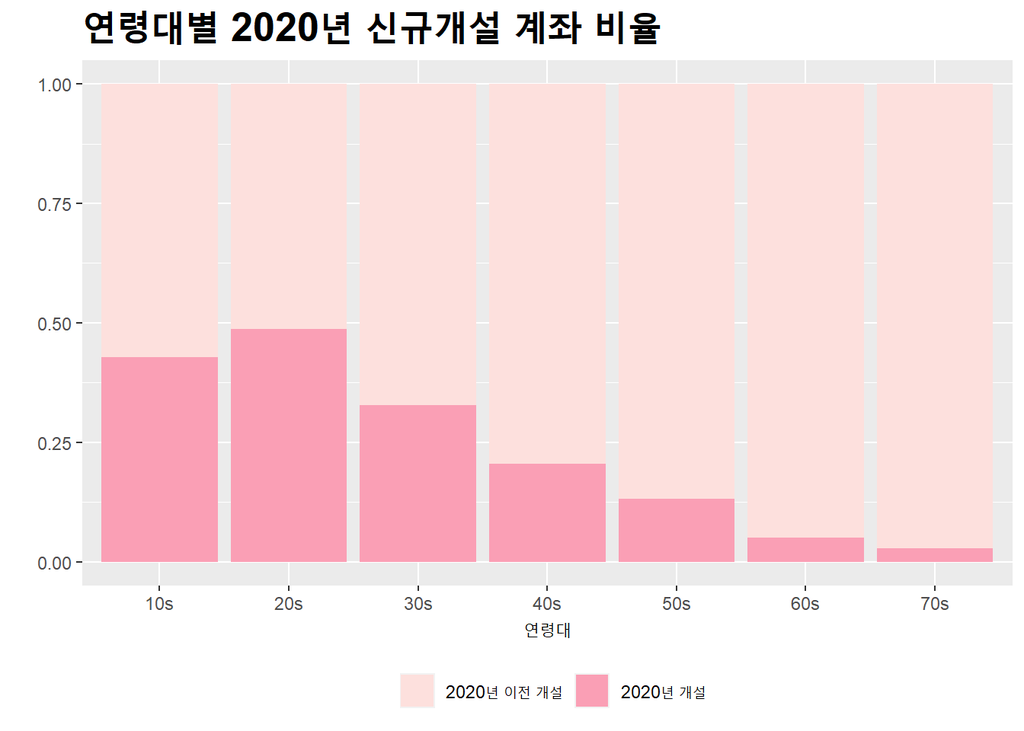

```r
data %>%
  # 신규계좌 개설 여부 파생변수 생성
  mutate(new_acc = ifelse(act_opn_yy == 2020, '2020년 개설', '2020년 이전 개설')) %>%
  # ggplot 시작
  ggplot(aes(x=cus_age, fill = factor(new_acc, # factor 순서 변경
                                      levels = c('2020년 이전 개설', '2020년 개설')))) +
  geom_bar(position = 'fill') +

  # 제목, 테마, 축 수정
  labs(title = '연령대별 2020년 신규개설 계좌 비율',
       x = '연령대', y = '', fill = "") +
  theme(plot.title = element_text(size = 20, face = 'bold'),
        legend.position = 'bottom') +
  scale_fill_brewer(palette = 'RdPu') # palette 지정
```

### 문제2. Line Graph (Time Series Graph)

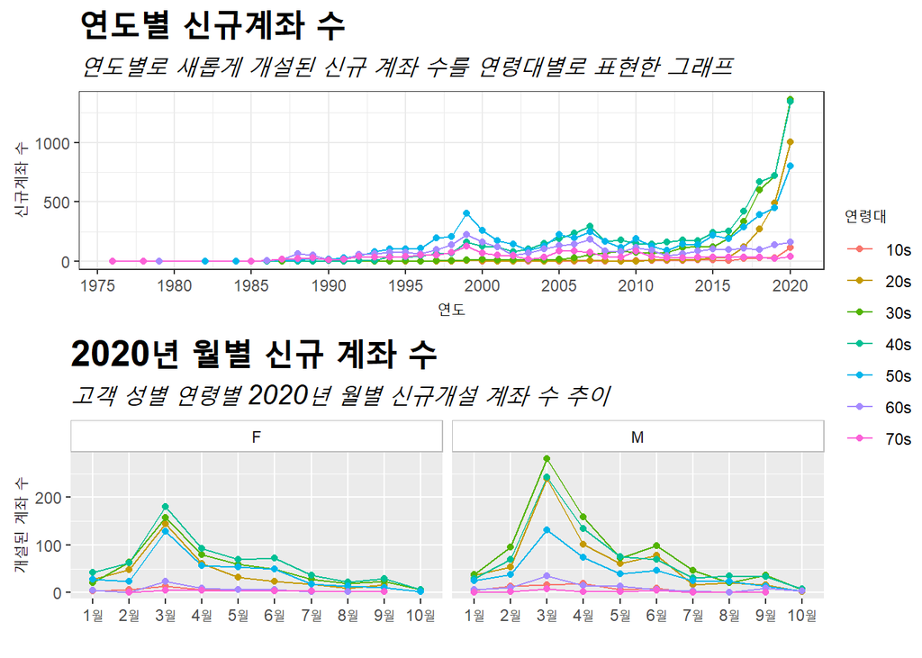

```r
line1 = data %>%
  group_by(act_opn_yy, cus_age) %>%
  summarise(count = length(act_id)) %>% # 연도별 신규계좌 수 생성

  # ggplot 시작
  ggplot(aes(x = act_opn_yy, y = count, color = cus_age)) + # 나이별로 그룹화
  geom_line() + geom_point() +

  # 제목, 테마, 축 수정
  theme_bw() +
  labs(title = '연도별 신규계좌 수',
       subtitle = '연도별로 새롭게 개설된 신규 계좌 수를 연령대별로 표현한 그래프',
       x = '연도', y = '신규계좌 수', color = '연령대') +
  theme(plot.title = element_text(size = 20, face = 'bold'),
        plot.subtitle = element_text(size = 15, face = 'italic')) +
  scale_x_continuous(breaks = seq(1975,2020,by=5)) # 5년마다 나오도록 x축 조정

ord = paste(1:12,'월',sep='') # 월별 순서 변수 생성
line2 = data %>%
  filter(act_opn_yy == 2020) %>% # 2020년도 계좌만 필터링
  group_by(act_opn_mm, cus_age, sex_dit_cd) %>%
  summarise(count = length(act_id)) %>%  # 월별 신규 계좌 수 생성

  # ggplot 시작
  ggplot(aes(x = factor(paste(act_opn_mm,'월',sep=""), levels = ord), # 월별로 순서 정렬
             y = count, group = cus_age, color = cus_age)) +
  geom_line() + geom_point() +
  facet_wrap(~ sex_dit_cd) + # 성별로 그룹화

  # 제목, 테마, 축 수정
  labs(title = '2020년 월별 신규 계좌 수',
       subtitle = '고객 성별 연령별 2020년 월별 신규개설 계좌 수 추이',
       x = '', y = '개설된 계좌 수', color = '연령대') +
  theme(plot.title = element_text(size = 20, face = 'bold'),
        plot.subtitle = element_text(size = 15, face = 'italic'),
        strip.background = element_rect(fill = 'white', color = 'grey'))


ggarrange(line1, line2, nrow=2, common.legend = TRUE, legend = 'right') # 공통 범례 사용
```

### 문제 3. Bar Graph + Line Graph

Chapter1 문제 11번에서 생성한 account_cnt를 사용하여 다음과 같이 연령대별 고객 분포를 bar graph로 표현하고, 인당 평균 계좌 개수를 line graph로 표현하여 시각화해주세요.

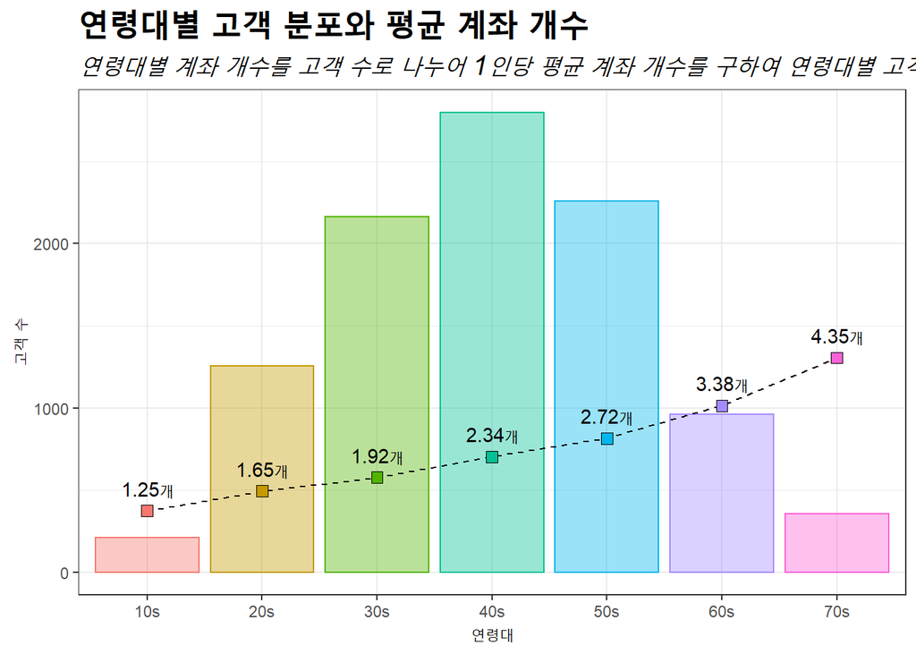

```r
account__cnt %>%
  ggplot(aes(x = cus_age)) +
  geom_col(aes(y = cus_cnt, fill = cus_age, color = cus_age), alpha = 0.4) +
  geom_line(aes(y = mean_act_cnt*300, group=1),linetype = 'dashed') +
  geom_point(aes(y = mean_act_cnt*300, fill = cus_age), shape = 22, size = 3) +
  geom_text(aes(y = mean_act_cnt*300,
                label = paste(round(mean_act_cnt,2),'개',sep='')), vjust = -1) +

  # 제목, 테마, 축 수정
  theme_bw() +
  labs(title = '연령대별 고객 분포와 평균 계좌 개수',
       subtitle = '연령대별 계좌 개수를 고객 수로 나누어 1인당 평균 계좌 개수를 구하여 연령대별 고객 분포와 함께 표현했습니다.',
       x = '연령대', y = '고객 수') +
  theme(plot.title = element_text(size = 20, face = 'bold'),
        plot.subtitle = element_text(size = 15, face = 'italic'),
        legend.position = 'None')
```

y축인 고객수의 최대값은 2000이 넘어감.  
반면에 평균계좌 개수의 최대값은 5가 넘지 않고 범위가 훨씬 좁음.  
따라서 300을 곱해 값을 조정, 그래프상에 잘 표현되도록 함.

### 문제 4. Scatter Plot & Box Plot

환경에 저장된 데이터를 모두 삭제하고 carData 패키지의 Salaries 데이터셋을 불러주세요. [rm(list=ls()) ; data(Salaries, package=”carData”) 코드 사용]

```r
rm(list=ls())
data(Salaries, package='carData')
```

#### 4-1. Salaries 데이터셋으로 다음과 같은 scatter plot을 시각화해주세요.

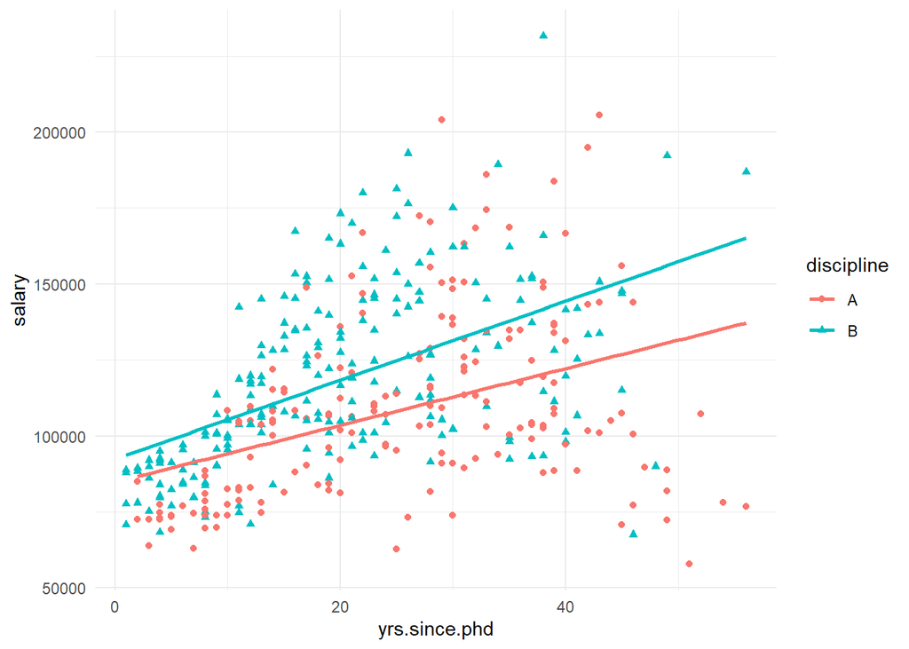

```r
Salaries %>%
  ggplot(aes(x = yrs.since.phd, y = salary,
             group = discipline, color = discipline)) +
  geom_point(aes(shape = discipline)) + # 점들의 모양 지정
  geom_smooth(method = 'lm', se = FALSE) + # 선형 회귀선으로 변형, 신뢰구간 표시 X
  theme_minimal()
```

#### 4-2[심화_기존은 필수, 신입은 선택] Salaries 데이터셋으로 다음과 같은 box plot을 시각화해주세요.

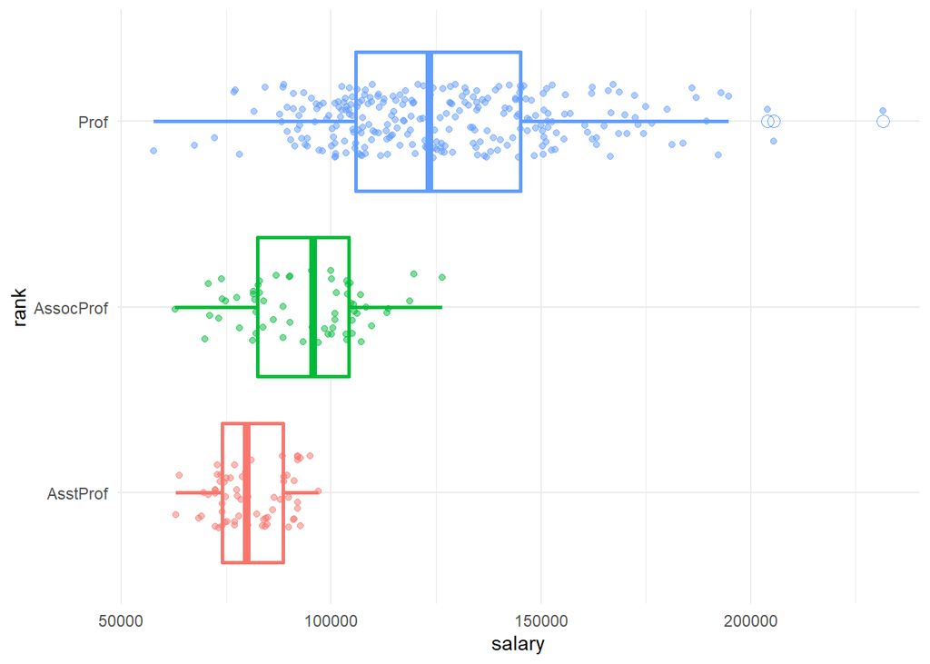

```r
Salaries %>%
  ggplot(aes(x = salary, y = rank, color = rank)) +
  geom_boxplot(lwd = 1, outlier.size = 3, outlier.shape = 1) + # 예시와 같이 outlier 맞춰주고 박스 넓이 증가시킴
  geom_jitter(alpha = 0.5, height=0.2) + # jitter통해 가독성 확보, 높이 맞춰줌
  theme_minimal() +
  theme(legend.position = 'None') # 범례 삭제
```

## Chapter3 회귀분석

#### 문제1. Salaries 데이터셋의 수치형 변수만을 선택하여 상관계수 플랏을 그리고 간단히 해석해보세요.

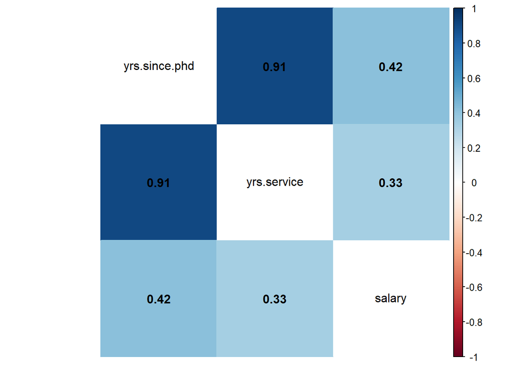

```r
Salaries %>%
  select(yrs.since.phd, yrs.service, salary) %>% # 수치형 변수들 선택
  cor %>% corrplot(method = 'color', tl.pos = 'd', tl.col = 'black', # text label의 위치와 색깔 변경
                   addCoef.col = 1, diag = F) # 상관계수 표시, 대각선은 제외
```

`yrs.since.phd`변수와 `yrs.service`변수간의 상관계수가 0.91로 강한 양의 상관관계를 보여줌.  
박사학위를 딴 시점과 일을 하기 시작한 시점이 비슷해서 그렇지 않을까 추정.

#### 문제2. [심화_기존은 필수, 신입은 선택] Salaries 데이터셋에서 성별에 따른 salary의 평균이 유의미하게 다른지 통계적으로 검증하고 싶습니다. 어떤 검정 방법을 사용할지 선택하 고, 검정을 진행한 뒤 그 결과를 해석해주세요.

```r
# 성별에 따른 salary 데이터 만들어줌
data = Salaries %>% group_by(sex) %>% summarise(salary)
Female_salary = data[data$sex == 'Female',2]
Male_salary = data[data$sex == 'Male',2]

# 양측검정 사용
t.test(Female_salary, Male_salary, alt='two.sided')
```

```
##
##  Welch Two Sample t-test
##
## data:  Female_salary and Male_salary
## t = -3.1615, df = 50.122, p-value = 0.002664
## alternative hypothesis: true difference in means is not equal to 0
## 95 percent confidence interval:
##  -23037.916  -5138.102
## sample estimates:
## mean of x mean of y
##  101002.4  115090.4
```

p-value가 0.002664로 유의수준 5%에서 유의한 결과 획득.  
즉, `성별에 따른 salary의 평균이 유의미하게 다르다.`라고 할 수 있음.

#### 문제3. 데이터를 7:3비율로 train/test를 분리하세요.

(2728 시드 고정 필수, p=0.7으 로 사용)

```r
set.seed(2728) # 시드 고정
train_idx = createDataPartition(Salaries$salary, p=0.7, list=F) # 7:3으로 인덱스 분리

# 데이터 생성
train = Salaries[train_idx,]
test = Salaries[-train_idx,]
```

#### 문제4. train 데이터를 이용하여 salary를 종속변수, 나머지 변수들을 독립변수로 하는 회귀 모형을 만든 뒤 결과를 간단히 해석해주세요.

(범주형 독립변수들은 어떻게 해석할 수 있는지도 설명해주세요.)

```r
fit = lm(salary~., data = train)
fit %>% summary
```

```
##
## Call:
## lm(formula = salary ~ ., data = train)
##
## Residuals:
##    Min     1Q Median     3Q    Max
## -63182 -13143  -1847  11327  87832
##
## Coefficients:
##               Estimate Std. Error t value Pr(>|t|)
## (Intercept)    69053.1     5237.9  13.183  < 2e-16 ***
## rankAssocProf  15116.9     4825.9   3.132  0.00192 **
## rankProf       45506.8     4904.2   9.279  < 2e-16 ***
## disciplineB    12783.4     2676.0   4.777 2.91e-06 ***
## yrs.since.phd    279.3      283.8   0.984  0.32592
## yrs.service     -274.3      242.7  -1.130  0.25932
## sexMale         2892.8     4629.9   0.625  0.53261
## ---
## Signif. codes:  0 '***' 0.001 '**' 0.01 '*' 0.05 '.' 0.1 ' ' 1
##
## Residual standard error: 21630 on 273 degrees of freedom
## Multiple R-squared:  0.4553, Adjusted R-squared:  0.4433
## F-statistic: 38.03 on 6 and 273 DF,  p-value: < 2.2e-16
```

F-검정통계량의 p-value가 유의하므로 `모든 회귀계수가 0이다`라는 귀무가설 기각.  
`rank`: 부교수와 정교수 모두 조교수보다 평균 수입이 더 높음.  
`discipline`: B인 경우가 A인 경우보다 평균 수입이 더 높음.  
나머지 변수는 salary에 유의한 영향 X

#### 문제5. 회귀모형의 성능을 평가할 수 있는 지표가 무엇인지 설명하고, 모델의 train error와 test error를 계산한 뒤 비교해주세요.

회귀모형의 성능 지표로 대표적인 `RMSE`를 사용  
루트를 사용해 제곱으로 생기는 왜곡 해소하는 장점 있음.

```r
# train error
pred_train = predict(fit,train)
train_error = rmse(train$salary,pred_train)

# test error
pred_test = predict(fit,test)
test_error = rmse(test$salary,pred_test)

cat('train error: ',  train_error,'\n', 'test error: ', test_error)
```

```
## train error:  21358.84
##  test error:  24785.88
```

`train error`가 `test error`에 비해 약 3400정도 더 낮음.